# Bellevue Waze Hot Spot Mapping

Safety Data Initiative | Volpe

## Overview

Mapping of compiled Waze events from April 2017 to November 2018 in Bellevue, WA. Events within 6 miles of the center of Bellevue were included in this initial work; one of the next steps will be to clip to the city boundary shapefile. In addition, the Bellevue road network has not yet been incorporated in these maps. A base layer derived from Open Street Maps is used for these maps.

Ten most frequent street names for all Waze incident reports in study period

| Street | Frequency |
| --- | --- |
| I-405 S | 112,414 |
| I-405 N | 64,353 |
| I-90 W | 60,435 |
| I-90 E | 37,207 |
| SR-520 W | 33,015 |
| SR-520 E | 18,746 |
| Coal Creek Pkwy SE | 12,847 |
| W Lake Sammamish Pkwy SE | 12,026 |
| 148th Ave NE | 11,690 |
| I-405 N Exp Toll Ln | 11,069 |

In the Waze data, there are two ways to make an initial filter to omit roads which are not in the jurisdiction of Bellevue: to filter by street names, and also to filter by road class. Waze uses their own road classification system; interstates are all class ‘3’ in the Waze system.

Here we filter the Waze data by excluding I-405, I-90, as well as SR-520 (assuming this is not in Bellevue jurisdiction), and by omitting any additional events on class 3 roads. Filtering by name effectively removes nearly all class 3 roads. Some Waze events missing a street name and with an incorrect road class may still appear on the interstates after this filtering process; a GIS approach to snap Waze events to road segments will also be necessary.

Ten most frequent street names for all Waze incident reports, omitting highways, in study period

| Street | Frequency |
| --- | --- |
| Coal Creek Pkwy SE | 12,555 |
| W Lake Sammamish Pkwy SE | 11,457 |
| 148th Ave NE | 11,170 |
| to I-405 N / Everett | 8,263 |
| Bellevue Way SE | 7,207 |
| to I-405 S / Renton | 5,834 |
| 148th Ave SE | 5,790 |
| E Lake Sammamish Pkwy NE | 5,557 |
| to I-90 W / Seattle | 5,035 |
| W Lake Sammamish Pkwy NE | 4,633 |

## Heat maps

The following heat maps show 2-D kernel density estimates of incident frequency. Warm colors indicate high frequency, cool colors show lower frequency. Maps are shown with and without individual incidents plotted for clarity.

### All Waze crash reports

16,971 Waze crash reports.

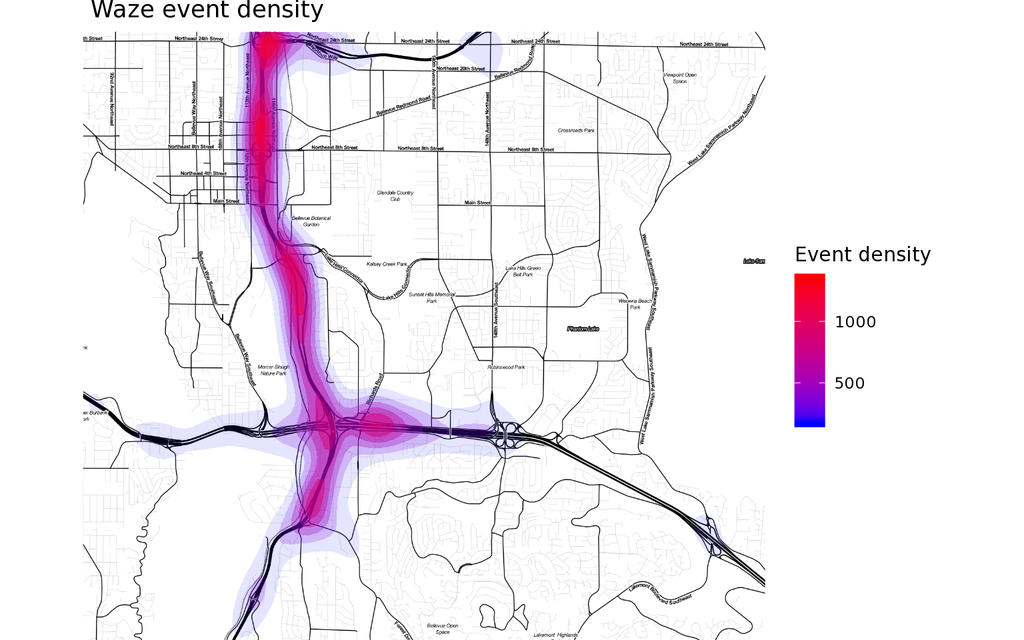

[figure not shown]

### Waze crash reports, omitting highways

5,498 Waze crash reports, after filtering out highways.

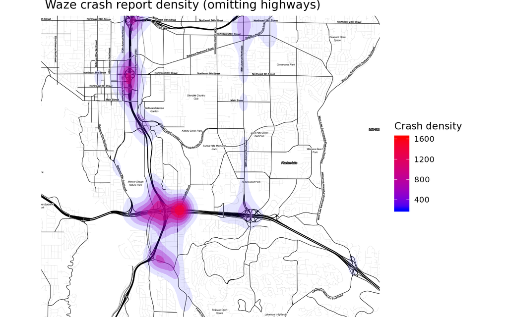

[figure not shown]